# PCA Analysis

Author

Juliette Tariel-Adam

Published

February 4, 2025

We tried a PCA on:

- scaled variables.
  - All variables are divided by their standard deviation and have therefore the same variance / standard deviation of 1. It is the standard PCA.
  - But the problem with PCA on scaled variables it that it cannot quantitatively interpret the differences between treatments (for instance we can’t say 100 sec resting more in Large than Barren). It stays a qualitative analysis (for instance more time spent resting in Large than Barren). A solution is to then give some numbers by calculating them on raw behavioural types.
- non-scaled variables. All behavioural variables have the same unit, which means we can do a PCA without scaling the variables. The variables with the higher variance will contribute more to the PCA.
  - PCA using non-scaled variables can quantitatively interpret the differences.
  - But it gives more importance to behavioural variables that have the more variance. And I don’t see why we should give more importance to certain variables or not. A difference of 10 sec in stereotypic swimming might be as relevant as a difference of 50 s swimming.

So we decide to do PCA using scaled variables because of this last point: we don’t want to give more importance to behaviours with the most variance. (And also the circle of correlations looks worst with non-scaled variables = less easy to interpret. As our behaviour variables were very different in variance, the length of the arrows in the circle of correlations are very different).

Also, I was concerned of running PCA on repeated measures, but apparently it is not a big deal.

**Scaled variables**

```r
pcaS <- PCA(data[,beh.cols], graph = FALSE, scale.unit = TRUE)
pcaS$eig
```

```
       eigenvalue percentage of variance cumulative percentage of variance
comp 1 1.99367384             28.4810549                          28.48105
comp 2 1.27919452             18.2742074                          46.75526
comp 3 1.21631822             17.3759745                          64.13124
comp 4 1.10583365             15.7976236                          79.92886
comp 5 0.84562429             12.0803469                          92.00921
comp 6 0.55086261              7.8694659                          99.87867
comp 7 0.00849287              0.1213267                         100.00000
```

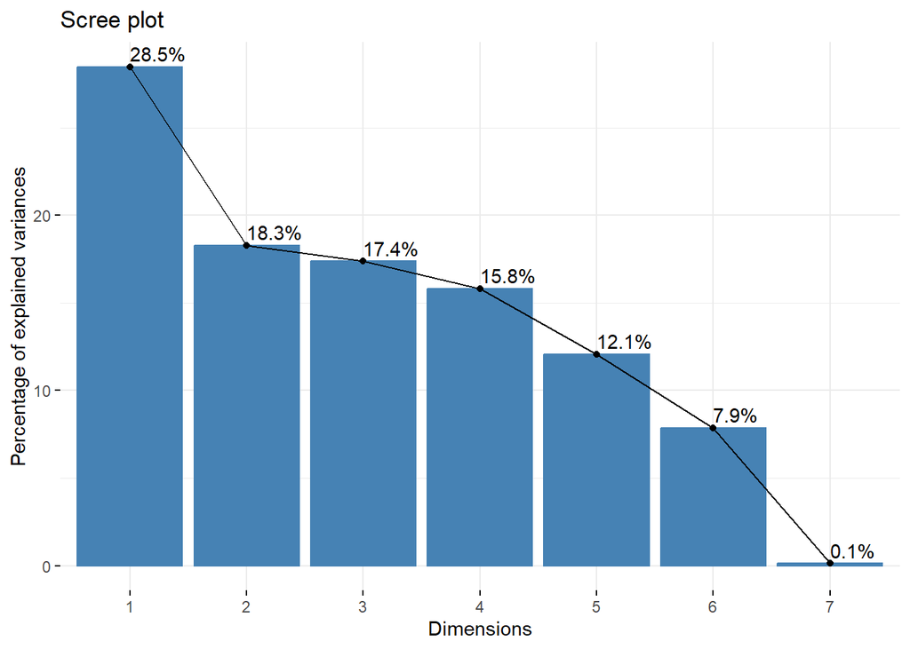

```r
fviz_eig(pcaS, addlabels = TRUE)
```

Rules to keep an component:

- eigen value > 1
- Cumulative percentage of variance > 95%
- component before the drop

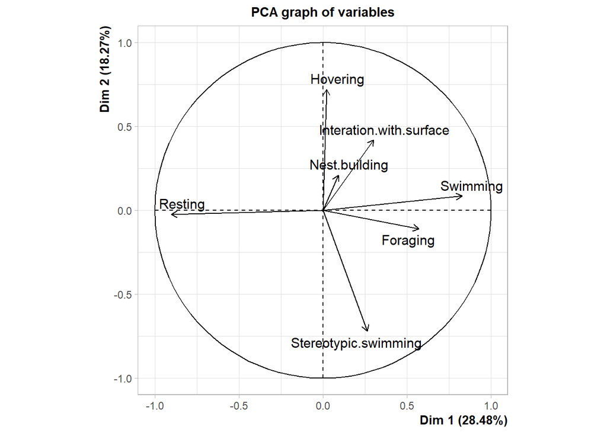

```r
pcaS <- PCA(data[,beh.cols], ncp=4,graph = FALSE, scale.unit = TRUE)
plot(pcaS, choix = "var", axes = c(1,2))
```

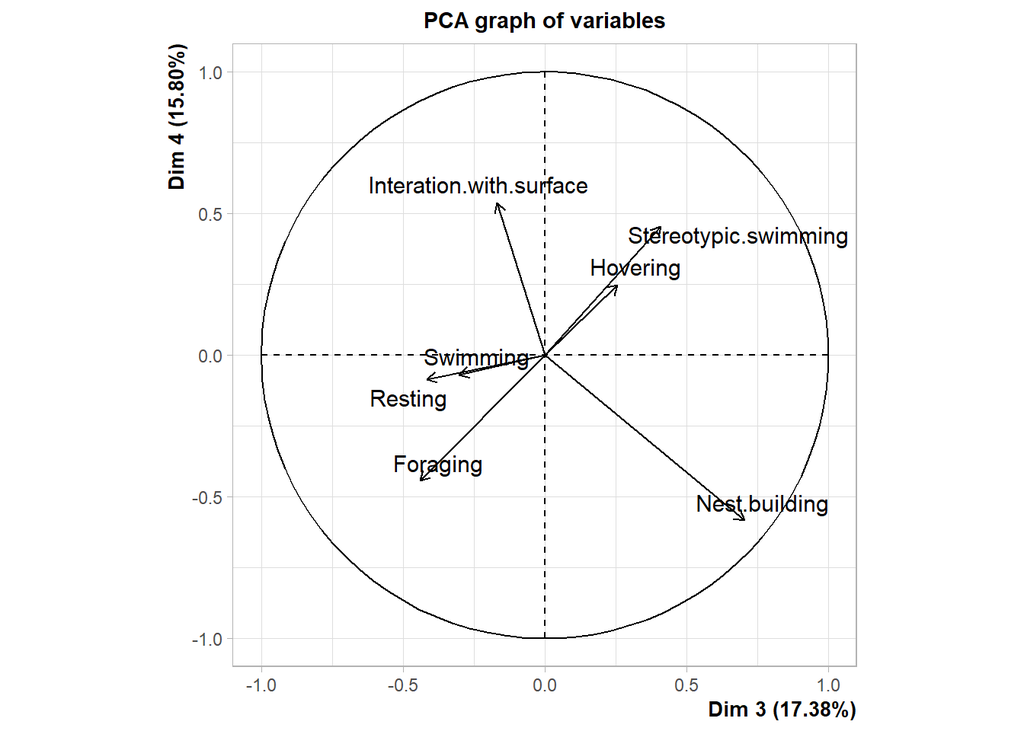

```r
plot(pcaS, choix = "var", axes = c(3,4))
```

```r
# how well each variable correlates with and contributes to the variation explained by each principal component
round(pcaS$var$cos2,1)
```

```
                        Dim.1 Dim.2 Dim.3 Dim.4
Swimming                  0.7   0.0   0.1   0.0
Resting                   0.8   0.0   0.2   0.0
Hovering                  0.0   0.5   0.1   0.1
Stereotypic.swimming      0.1   0.5   0.2   0.2
Nest.building             0.0   0.0   0.5   0.3
Foraging                  0.3   0.0   0.2   0.2
Interation.with.surface   0.1   0.2   0.0   0.3
```

```r
# extent to which each variable contributes to the total variance explained by the first 4 components
rowSums(pcaS$var$contrib)
```

```
               Swimming                 Resting                Hovering
               42.86546                55.71955                51.74578
   Stereotypic.swimming           Nest.building                Foraging
               76.42204                75.39455                51.11117
Interation.with.surface
               46.74144
```

```r
# extent to which each variable contributes to the total variance explained by the first 3 components
rowSums(pcaS$var$contrib[,1:3])
```

```
               Swimming                 Resting                Hovering
               42.44136                55.07072                46.15749
   Stereotypic.swimming           Nest.building                Foraging
               57.83766                44.57373                33.30029
Interation.with.surface
               20.61874
```

- 1st axis: Swimming, Foraging vs Resting
- 2nd axis: Hovering vs Stereotypic swimming
- 3rd axis: Mostly Nest.building vs Foraging
- 4th axis: almost all variables, difficult to interpret

Sinking.Floating (and to a lesser extent Interaction.with.surface) is not very useful for the first 4 components, so not useful to explain the variability between trials (and this even though they are scaled = contribute to the PCA to the same extent that variables with higher initial variance).

Below plot of the first two components with tank or fish ellipses overlaid.

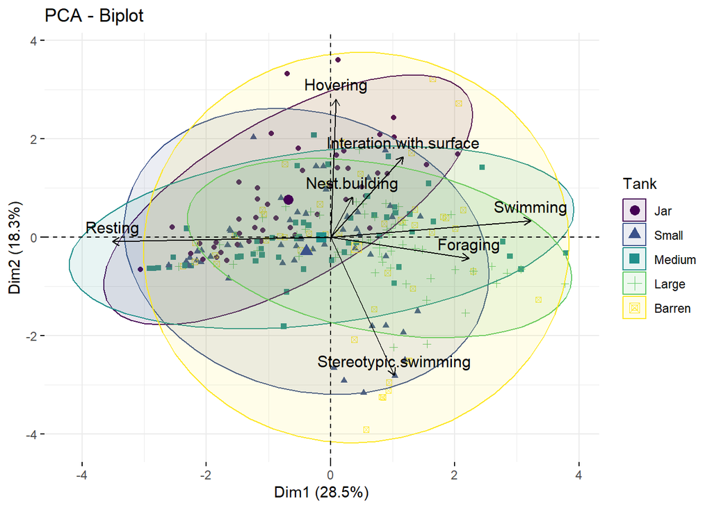

```r
fviz_pca_biplot(pcaS, geom.ind = "point", col.ind = data$Tank, col.var="black",
                            addEllipses = TRUE, legend.title = "Tank", palette = viridis(5))
```

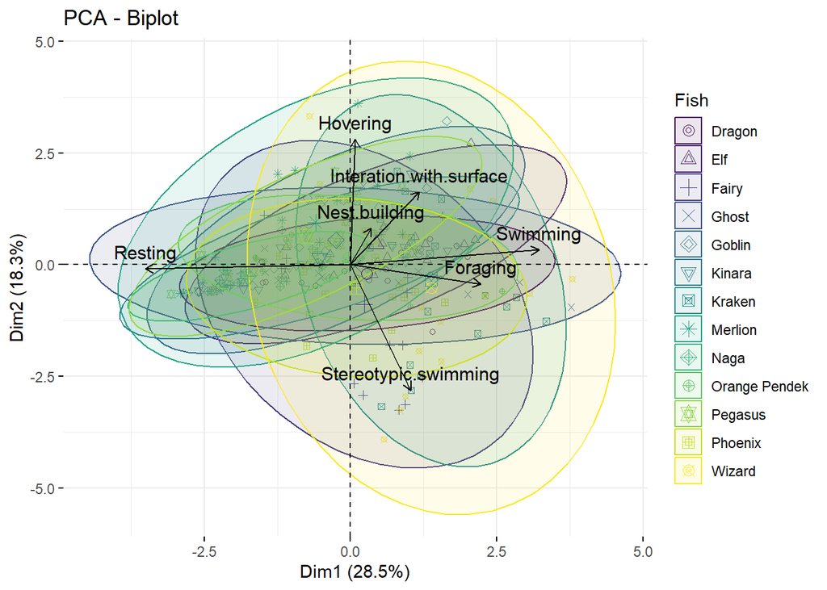

```r
fviz_pca_biplot(pcaS, geom.ind = "point", col.ind = data$Fish, col.var="black",
                            addEllipses = TRUE, legend.title = "Fish", palette = viridis(13))
```

No clear distinction between the different tanks or fish. Common in behaviour ecology to not have clear groups.

**Non-scaled variables**

Resting and Swimming have the highest variance (see below) and they will therefore contribute more to the PCA using non-scaled variables. Sinking.Floating, Foraging and Hovering have the lowest variances.

```r
apply(data[,beh.cols], 2, var) # variance of each variable
```

```
               Swimming                 Resting                Hovering
             11870.9451              26738.2171               2938.9565
   Stereotypic.swimming           Nest.building                Foraging
             10796.2814               7041.0466                314.5212
Interation.with.surface
              1114.0036
```

```r
pcaNS <- PCA(data[,beh.cols], graph = FALSE, scale.unit = FALSE)
pcaNS$eig
```

```
        eigenvalue percentage of variance cumulative percentage of variance
comp 1 34667.58726             57.2330736                          57.23307
comp 2 11815.22484             19.5058753                          76.73895
comp 3  8976.18729             14.8188792                          91.55783
comp 4  3535.83400              5.8373444                          97.39517
comp 5  1195.24795              1.9732470                          99.36842
comp 6   315.72079              0.5212267                          99.88965
comp 7    66.84416              0.1103537                         100.00000
```

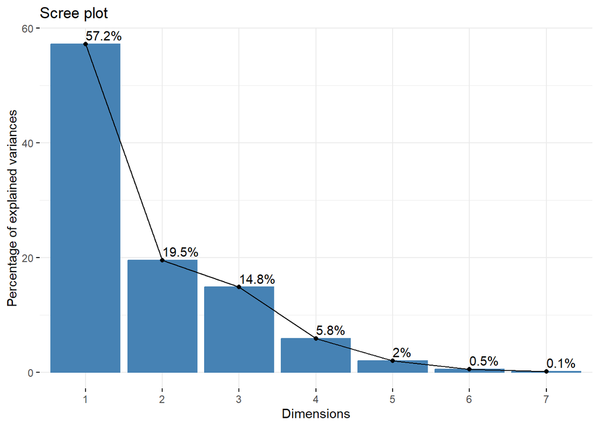

```r
fviz_eig(pcaNS, addlabels = TRUE)
```

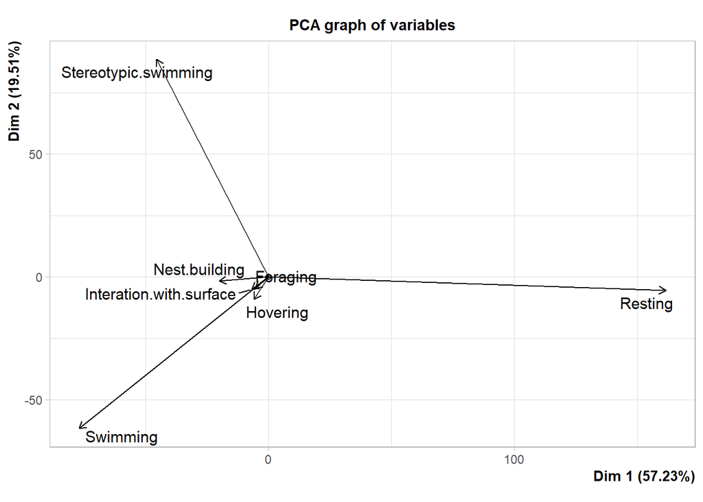

```r
# if we keep 4 variables
pcaNS <- PCA(data[,beh.cols], ncp=4,graph = FALSE, scale.unit = FALSE)
plot(pcaNS, choix = "var", axes = c(1,2))
```

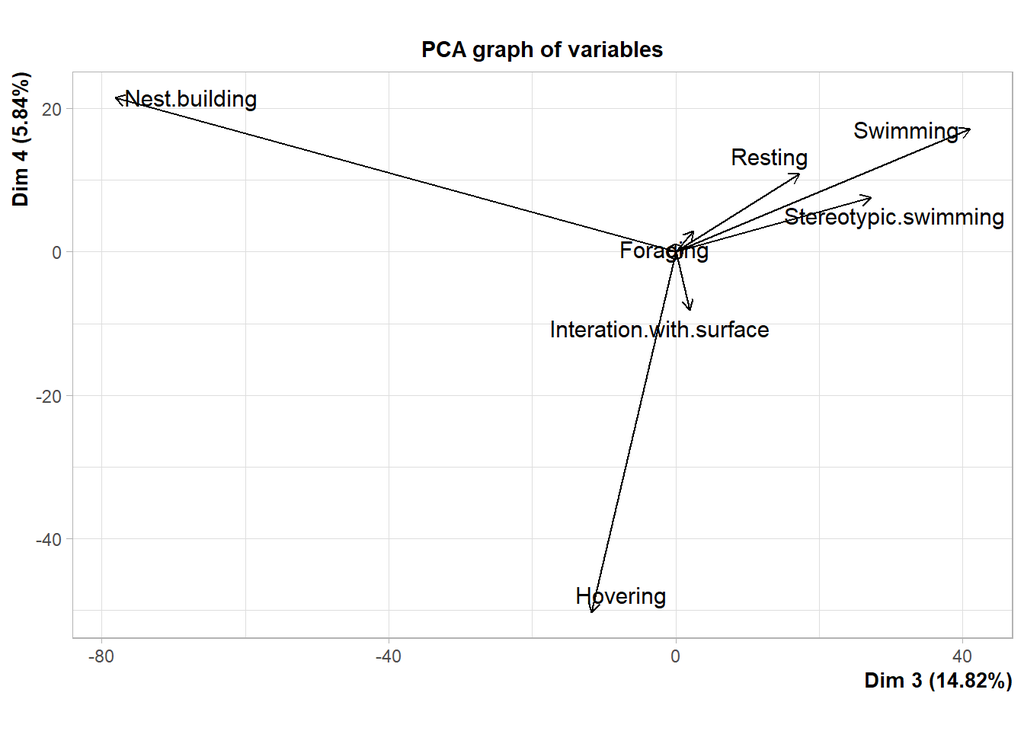

```r
plot(pcaNS, choix = "var", axes = c(3,4))
```

```r
round(pcaNS$var$cos2,1)
```

```
                        Dim.1 Dim.2 Dim.3 Dim.4
Swimming                  0.5   0.3   0.1   0.0
Resting                   1.0   0.0   0.0   0.0
Hovering                  0.0   0.0   0.0   0.9
Stereotypic.swimming      0.2   0.7   0.1   0.0
Nest.building             0.1   0.0   0.9   0.1
Foraging                  0.1   0.1   0.0   0.0
Interation.with.surface   0.0   0.0   0.0   0.1
```

```r
rowSums(pcaNS$var$contrib)
```

```
               Swimming                 Resting                Hovering
              76.498853               82.342630               73.856223
   Stereotypic.swimming           Nest.building                Foraging
              82.201162               82.268528                0.572337
Interation.with.surface
               2.260267
```

Using the cumulative percentage of variance’s rule, 4 variables will be enough. 3 axis might be good enough as the 4th axis is bringing only 6% of variance.

- 1st axis: Resting vs Swimming, Stereotypic.swimming
- 2nd axis: Swimming vs Stereotypic swimming
- 3rd axis: Mostly Nest.building
- 4th axis: Mostly Hovering

Again Sinking.Floating is not explaining a lot of variance. Hovering is important because even if its variance is low, it is explaining some variance in the data.